# 2019 Sales Data Analysis

## by Augustine Phiri

## Investigation Overview

> The project was focused much on answering the following questions:
- What was the best month for sales? how much was earned in that month?
- what product had the highest sales? and Why?
- What city hard the highest sales? How much was earned in that city?
- What time should we display advertisements to maximize likelihood of customer's buying the product?

> So in summary, it was observed that the month of december had highest sales with $ 4613443.34 compared to the rest of the Months, and month of January had the lowest sales. This may be attributed to the fact that in the month of december we have a lot of holidays and entainments compared to the rest of the months in the year.

> From the results it the highest sales were in San Francisco CA with $ 8262203.91.

< Recommandation can also be made on what time we need to be advertising these products. It is my recommendation that the advertisements be made slightly before 11 am upto around 12 pm and then slightly before 7pm upto around slightly 8 pm everyday.

## Dataset Overview

> In this data analysis project, I used python libriaries (pandas, numpy, matplotlib, os, seanborn. This data was gotten from youtube, it was different product data recording sales from January to December 2019. The data contained 186850 rows and 6 columns. The columns included Order Id, Product, Quantity Ordered, Price Each, Order Date and Purchase Address.

> After analysis, it was observed that month of December (month number 12) was the best month for sales with `$ 4,613, 443.34` This was presented in a graph form for easy understanding.

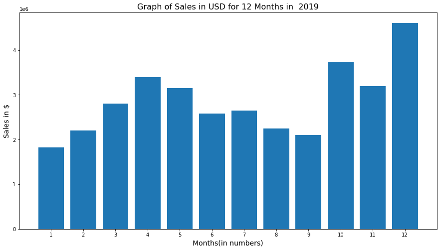

[figure not shown]

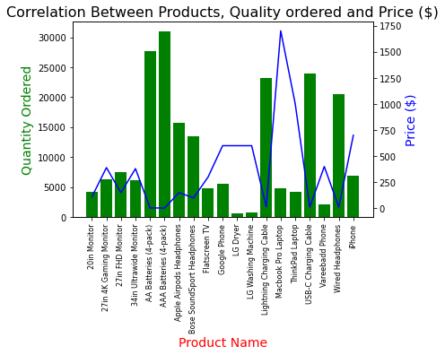

> The highest sales were in San Francisco CA with $ 8262203.91

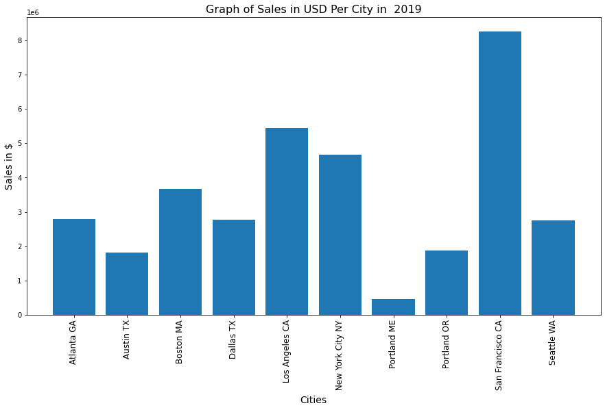

> We can clearly see that it is profitable if we post our advertisements slightly before 11 am upto around 12 pm and then slightly before 7pm upto around slightly 8 pm everyday.

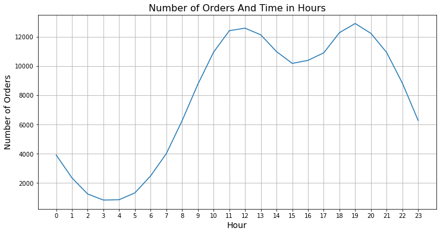